# Codi per al processament i l’anàlisi del microbioma

Guillem Vila Tubau

16/4/2021

[figure not shown]

# 1 Instal·lació de llibreries

El primer pas per convertir els fitxers fastq provinents de la seqüenciació en taules d’ASVs és assegurar-nos que tenim instal·lades les llibreries necessaries

```r
#Directori de treball
setwd("C:/Users/Usuari/Desktop/TFG/Codi/Workspace")
#Paquets de cran
install.packages("ggplot2")
install.packages("gridExtra")
install.packages("vegan")
install.packages("devtools")
install.packages("ggpubr")
install_url(url="https://github.com/UVic-omics/selbal/archive/master.zip", INSTALL_opt= "--no-multiarch")
devtools::install_github("egr95/R-codacore", ref="main")
#Paquets de bioconductor
if (!requireNamespace("BiocManager", quietly = TRUE))
  install.packages("BiocManager")
BiocManager::install("dada2")
BiocManager::install("phyloseq")
BiocManager::install("DECIPHER")
BiocManager::install("phangorn")
BiocManager::install("ALDEx2")
#Cridem llibreries
library(ggplot2)
library(gridExtra)
library(dada2)
library(phyloseq)
library(DECIPHER)
library(phangorn)
library(vegan)
library(devtools)
library(selbal)
library(ALDEx2)
library(codacore)
library(ggpubr)
```

# 2 Preparació de les dades

A continuació hem d’indicar en quin directori es troba la carpeta on hi ha els fitxers FASTQ comprimits (.gz) de la seqüenciació. En aquest cas l’he col·locat dins el directori de treball però és possible indicar el camí a qualsevol directori. Això facilita determinar el camí a cada fitxer FASTQ.

```r
#Directori de la carpeta PRJEB13092 amb els fastqs
files <- "./PRJEB13092"
#Ordenem per si no estan en ordre (forwards abans que reverse), en aquest cas identifiquem si es tracta del forward o del reverse amb pattern _1 o _2 (pattern detecta patrons en el nom dels fitxers), en cas de només haver-hi un fastq per mostra no caldria fer aquest pas
forwards <- sort(list.files(files, pattern="_1"))
reverses <- sort(list.files(files, pattern="_2"))
#Extraiem nom de les mostres separant per _ i eliminant el que queda a la dreta
samples <- sapply(strsplit(forwards, "_"), `[`, 1)
#I finalment indiquem el camí des del directori de treball a cada fastq
forwards <- file.path(files, forwards)
reverses <- file.path(files, reverses)
```

## 2.1 Filtrat

Una vegada tenim els camins a les dades apunt i hem extret els noms de les mostres podem procedir a filtrar les lectures de baixa qualitat. Fer fer-ho primer hauriem d’avaluar la qualitat de les lectures de les nostres dades en funció de la posició per determinar en quin punt tallar.

```r
#Distribució de la qualitat en funció de la posició pels primers quatre forwards i reverses, estaria bé mirar-ne uns quants a l'atzar per veure si la distribució és més o menys homogènia
plotQualityProfile(forwards[1:4])
plotQualityProfile(reverses[1:4])
#Indiquem on volem crear la carpeta amb els FASTQ filtrats
filtered <- file.path(files, "filtered")
#Comprovem si ja existeix i en cas negatiu la creem
if(!file_test("-d", filtered)) dir.create(filtered)
#Assignem nom als FASTQ filtrats, en aquest cas només afegeixo _filt al final del nom
filtforward <- file.path(filtered, paste0(samples, "_1_filt.fastq.gz"))
filtreverse <- file.path(filtered, paste0(samples, "_2_filt.fastq.gz"))
#Filtrem, en aquest cas tallem a partir de 240 en els forwards i 160 en els reversos (encara que la seva qualitat sigui bastant dolenta)
filtntrim <- filterAndTrim(forwards, filtforward, reverses, filtreverse, truncLen=c(240,160), maxEE=c(2,2))
#Finalment observem el resultat
head(filtntrim)
```

## 2.2 Desreplicació

A continuació desrepliquem els fitxers filtrats, ajuntant totes les seqüencies idèntiques, estimem les taxes d’error, i estimem les variants de seqüencia d’amplicó (ASV).

```r
#Desrepliquem els fitxers filtrats
derepForward <- derepFastq(filtForward, verbose=TRUE)
derepReverse <- derepFastq(filtReverse, verbose=TRUE)
#Canviem el nom per el de les mostres
names(derepForward) <- samples
names(derepReverse) <- samples
#Estimem taxes d'error de la desreplicació
errorsForward <- learnErrors(derepForward)
errorsReverse <- learnErrors(derepReverse)
#Representació gràfica dels errors
plotErrors(errorsForward)
plotErrors(errorsReverse)
#Estimem les variants de seqüencia d'amplicó
dadaForward <- dada(derepForward, errorsForward)
dadaReverse <- dada(derepReverse, errorsReverse)
```

# 3 Construcció de la taula de seqüències i assignació de taxonomia

Ara toca ajuntar les lectures forward i reverse, construir una taula amb el nombre de lectures per cada ASV, i eliminar quimeres (resultat de la unió de dues o més seqüències durant el procés d’amplificació per PCR) i després assignar una taxonomia a cada ASV a través d’un alineament amb un fitxer FASTA de referència.

```r
#Unim forwards i reversos
mergedPairs <- mergePairs(dadaForward, derepForward, dadaReverse, derepReverse)
#Taula de seqüencies amb els parells units
sequenceTable <- makeSequenceTable(mergedPairs)
table(nchar(getSequences(sequenceTable)))
#Eliminem quimeres
sequenceTableChimera <- removeBimeraDenovo(sequenceTable)
#Indiquem quin és el fitxer de referència
refFasta <- "./rdp_train_set_18.fa.gz"
#Assignació taxonomia
taxonomyTable <- assignTaxonomy(sequenceTableChimera, refFasta = refFasta)
```

Amb això ja tenim la nostra taula d’ASVs sense quimeres (sequenceTableChimera) i de taxonomia (taxonomyTable).

# 4 Construcció de l’arbre filogenètic

El següent pas és la construcció de l’arbre filogenètic.

```r
#Agafem les seqüencies
sequences <- getSequences(sequenceTableChimera)
names(sequences) <- sequences
#Alineem les seqüencies
align <- AlignSeqs(DNAStringSet(sequences))
#Passem a matriu per poder fer servir phyDat
alignMatrix <- as(align, "matrix")
#Passem a format phyDat per poder calcular distàncies, indiquem que es tracten de seqüències d'ADN
phyDat <- phyDat(alignMatrix, type="DNA")
#Calculem distàncies entre seqüències
dist <- dist.ml(phyDat)
#Creem arbre amb Neighbor-Joining
tree <- NJ(dist)
#Optimitzem
fit = pml(tree, data=phyDat)
fitGTR <- update(fit, k=4, inv=0.2)
fitGTR <- optim.pml(fitGTR, model="GTR", optInv=TRUE, optGamma=TRUE, rearrangement = "stochastic", control = pml.control(trace = 0))
detach("package:phangorn", unload=TRUE)
```

# 5 Construcció de l’objecte phyloseq

Finalment ajuntarem tots els components que hem anat construïnt en un objecte phyloseq amb les metadades per facilitar l’exportació i importació de les dades processades i també la seva manipulació.

```r
#Llibreria per llegir l'excel
install.packages("readxl")
library(readxl)
#Llegim excel que conté les metadades
metaData <- read_excel("PRJEB13092 meta.xlsx")
#Passem a dataframe per facilitar el treballar-hi
metaData <- as.data.frame(metaData)
#Assignem com a nom de les files el RunID, que és el nom amb el qual hem estat treballant fins ara ja que era el nom que havíen donat als fitxers a la base de dades
rownames(metaData) <- metaData$RunID
#Seleccionem les columnes que volem conservar, en aquest cas totes
keep.cols <- c(colnames(metaData))
#Ens quedem només amb les mostres contingudes a la taula de seqüències
metaData <- metaData[rownames(sequenceTable), keep.cols]
#Creem objecte phyloseq mab la taula d'OTUs, les metadades, la taula de taxonomia i l'arbre filogenètic
phyloseq <- phyloseq(otu_table(sequenceTableChimera, taxa_are_rows=FALSE), sample_data(metaData), tax_table(taxonomyTable), phy_tree(fitGTR$tree))
#Assignem nom a les ASVs per fer-les més fàcilment identificables
taxanames<-taxa_names(phyloseq)
taxa_names(phyloseq)<-paste("ASV", 1:length(taxanames), sep = "")
#Exportem objecte phyloseq al directori de treball
saveRDS(phyloseq, file = "phyloseq.rds")
```

Això conclou la primera part del tutorial. Ara ja tenim el nostre objecte phyloseq i podem passar a la part de l’anàlisi.

# 6 Carregar objecte phyloseq i preprocessament

En primer lloc podem carregar l’objecte phyloseq que acabem de crear mitjançant readRDS. Pot ser útil si la primera part del tutorial s’ha fet en un altre ordinador per falta de RAM o qualsevol altre problema. Una vegada tenim el nostre objecte phyloseq eliminem les ASVs que no sumen més d’un cert nombre de lectures i fem el mateix amb les mostres.

```r
#Llegim el fitxer rds que conté l'objecte phyloseq
phyloseq <- readRDS("phyloseq.rds")

#Eliminació d'ASVs amb menys de 10 lectures totals
phyloseq <- prune_taxa(taxa_sums(phyloseq) > 10, phyloseq)
#Eliminació de mostres amb menys de 10 lectures totals
phyloseq <- prune_samples(sample_sums(phyloseq) > 10, phyloseq)
```

# 7 Representacions diverses

Hi ha diverses representacions que ens poden ajudar a entendre les nostres dades. És interessant representar les abundàncies relatives i absolutes de diferents nivells taxonòmics, a poder ser separats per les condicions.

```r
#Transformació a abundàncies relatives
relAbu <- transform_sample_counts(phyloseq, function(x) x/sum(x))
#Aglomeració taxonòmica a nivell phylum, s'hauria de comprovar com està escrit el nom de la taxonomia que es vol aglomerar
phylum <- tax_glom(phyloseq, "Phylum")
#Comprovem si s'ha produït correctament
head(tax_table(phyloseq))
head(tax_table(phylum))
#Ja només tenim els phylums, però els noms segueixen sent els assignats a les OTUs
taxa_names(phylum)
#Podem canviar el nom de les OTUs pel dels phylums
taxa_names(phylum) <- tax_table(phylum)[, "Phylum"]
#Aglomeració taxonòmica a nivell phylum de les abundàncies relatives
relAbuPhylum <- tax_glom(relAbu, "Phylum")
#I tornem a canviar el nom
taxa_names(relAbuPhylum) <- tax_table(relAbuPhylum)[, "Phylum"]
#I finalment podem representar les abundàncies relatives i absolutes a nivell Phylum
plot_bar(phylum, fill = "Phylum", facet_grid = "Subject")
plot_bar(relAbuPhylum, fill = "Phylum", facet_grid = "Subject")
#El procés anterior es pot repetir amb qualsevol nivell taxonòmic d'interès
```

Amb les abundàncies absolutes:

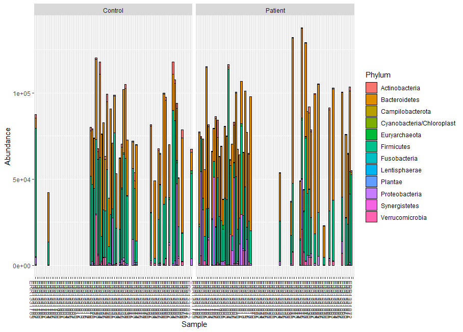

I amb les relatives:

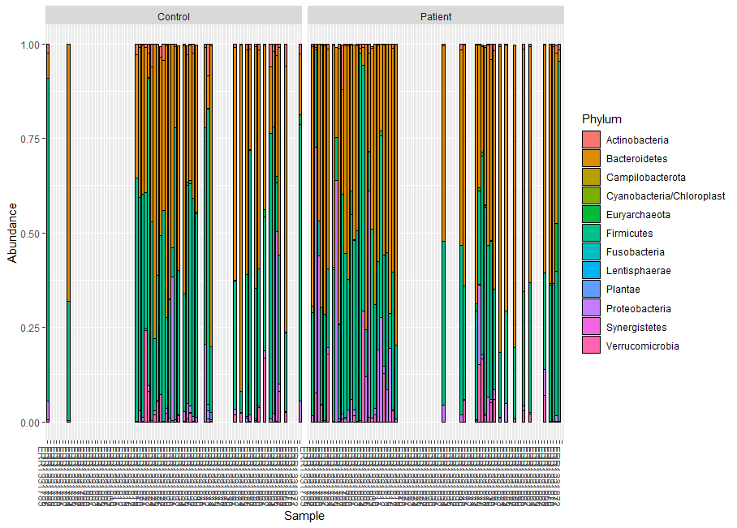

## 7.1 Aglomeració dels taxons menys freqüents

Una de les opcions per facilitar la representació dels fílums és l’agrupació dels taxons rars en una sola columna.

```r
#Mirem quants phylums tenen una abundància relativa total per sota de 0,1
sum(taxa_sums(relAbuPhylum) < 0.4)
#Vector amb els phylums menys abundants
minorPhylum <- which(taxa_sums(relAbuPhylum) < 0.4)
#I els agrupem per facilitar l'anàlisi
relAbuPhylumMin <- merge_taxa(relAbuPhylum, minorPhylum, 1)
#I els hi assignem un nom nou, el numero és la columna que ens hem quedat en el procés d'agrupar i sol ser la última
taxa_names(relAbuPhylumMin)[6]<-"Rare"
```

## 7.2 Diagrama de caixes , arbre filogenètic i heatmap

Altres opcions per representar les dades són fer un diagrama de caixes, que ajuda a veure quins són els taxons més i menys freqüents, i permet fer comparació entre les diferents condicions, i la representació d’un arbre filogenètic per veure la relació entre diferents unitats taxonòmiques i la seva abundància, també permetent la comparació entre les diferents condicions. També ensenyo com fer un heatmap que permet veure l’abundància de cada phylum per cada mostra.

```r
##Diagrama de caixes
#Agafem la taula d'OTUs de les abundàncies relatives a nivell phylum amb els menys freqüents agrupats
otu <- otu_table(relAbuPhylumMin)
#Representem el diagrama de caixes de la composició a nivell phylum per controls i pacients
subject <- sample_data(phyloseq)$Subject
#Seleccionem controls
otuControl <- subset(otu, subject=="Control")
#Seleccionem pacients
otuPatient <- subset(otu, subject=="Patient")
#Dos diagrames un al costat de l'altre
par(mfrow=c(1,2))
#Representem controls
boxplot(otuControl)
title("Controls")
#Representem pacients
boxplot(otuPatient)
title("Patients")
#Representació alternativa més informativa
df <- as.data.frame(otu_table(relAbuPhylumMin))
df["Subject"]=subject
ggboxplot(df, x = "Subject", y = c("Bacteroidetes", "Proteobacteria", "Firmicutes", "Verrucomicrobia", "Actinobacteria", "Rare"),
          combine = TRUE, color = "Subject", palette = "npg",
          add = "point", shape = "Grade")

##Arbre filogenètic
#Agrlomerar dades a nivell classe o qualsevol altre nivell taxonòmic d'interès
class<-tax_glom(phyloseq, "Class")
#Agafem el phylum que ens interessa representar
d<-subset_taxa(class, Phylum == "Firmicutes")
#Arbre filogenètic de les classes del phylum
plot_tree(d, ladderize="left", size="abundance", color="Subject", label.tips="Class")

##Heatmap
#Heatmap de l'abundància de cada phylum per cada mostra, invertim la intensitat del color
plot_heatmap(phylum, sample.label="Subject", low="#66CCFF", high="#000033", na.value="white")
```

Boxplots clàssics:

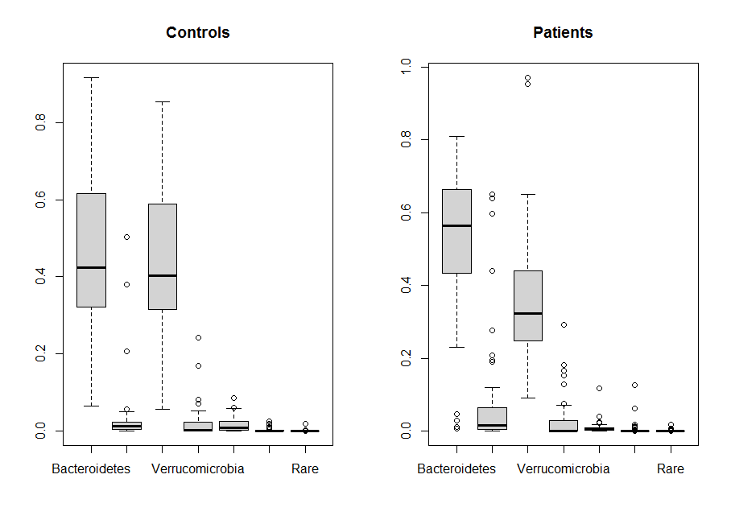

I els boxplots més informatius:

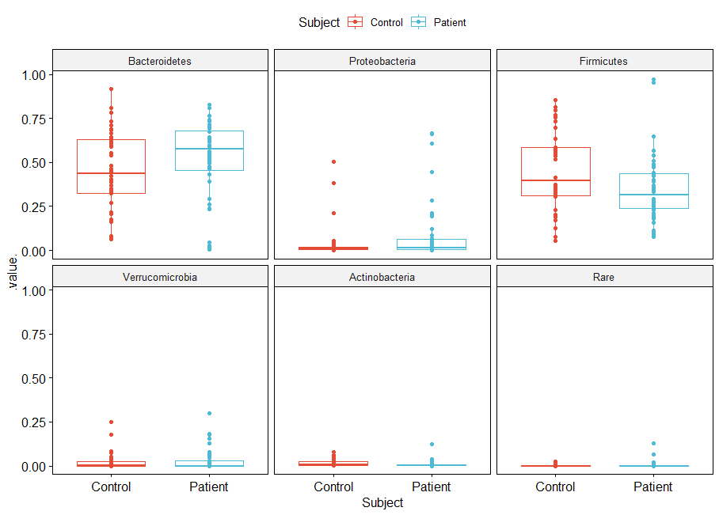

L’arbre filogenètic de les classes del fílum Firmicutes:

[figure not shown]

I finalment, el heatmap:

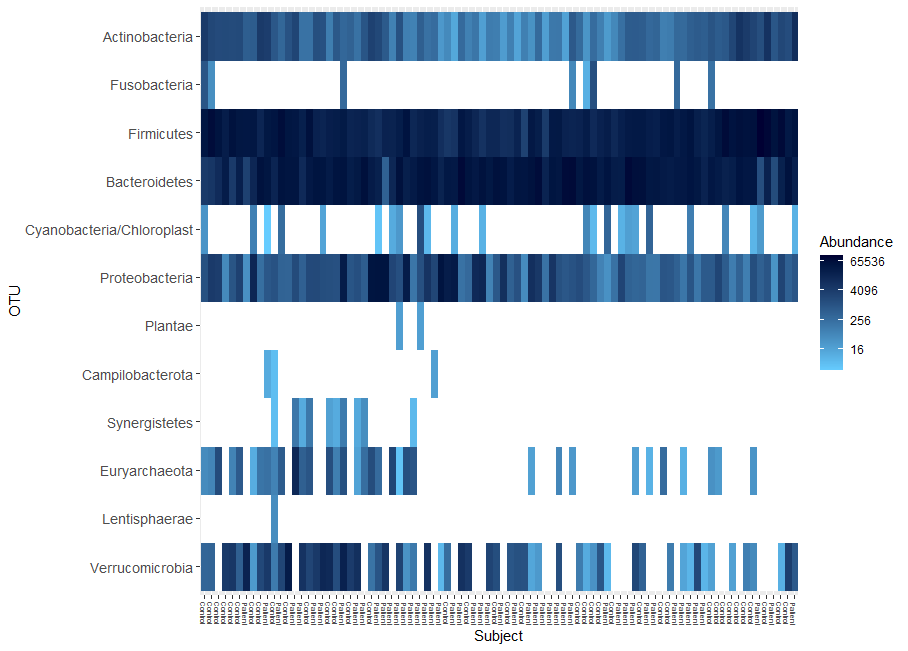

En aquest cas observem certes diferències entre el diagrama de caixes dels controls i el dels pacients a simple vista.

# 8 Diversitat alfa

El següent pas és l’estimació de la diversitat alfa o diversitat dins la mostra. Al fonament teòric de la memoria he descrit alguns dels principals mètodes per calcular-la.

```r
#Rarefaccionem les dades, necessari per comprovar l'efecte de la rarefacció sobre els resultats
raredata <- rarefy_even_depth(phyloseq, sample.size = min(sample_sums(phyloseq)), rngseed = 123)
subject <- sample_data(phyloseq)$Subject
#Diverses mesures de la diversitat alfa
alpha <- estimate_richness(phyloseq, measures =c("Observed", "Chao1", "Shannon", "Simpson"))
head(alpha)
PD <- pd(otu_table(phyloseq), phy_tree(phyloseq), include.root=FALSE)
#Representació gràfica de la diversitat alfa
plot_richness(phyloseq, x="Subject", measures=c("Observed","Chao1","Shannon", "Simpson"))
#Comparació de la diversitat alfa entre controls i pacients amb diagrama de caixes
par(mfrow=c(2,3))
boxplot(alpha$Observed~subject)
title("Observed by Subject")
boxplot(alpha$Chao1~subject)
title("Chao1 by Subject")
boxplot(alpha$Shannon~subject)
title("Shannon by Subject")
boxplot(alpha$Simpson~subject)
title("Simpson by Subject")
boxplot(PD$PD~subject)
title("Phylogenetic Diversity")
#En general els controls semblen tenir una diversitat més alta, anem a comprovar si les diferències són significatives amb una prova de Wilcoxon
wilcox.test(alpha$Observed~subject)
wilcox.test(alpha$Chao1~subject)
wilcox.test(alpha$Shannon~subject)
wilcox.test(alpha$Simpson~subject)
wilcox.test(PD$PD~subject)
#I una prova dels signes de Wilcoxon amb ajustament del valor p per FDR, no utilitzada en el treball
pairwise.wilcox.test(alpha$Observed, subject, p.adjust.method ="fdr")
pairwise.wilcox.test(alpha$Chao1, subject, p.adjust.method ="fdr")
pairwise.wilcox.test(alpha$Shannon, subject, p.adjust.method ="fdr")
pairwise.wilcox.test(alpha$Simpson, subject, p.adjust.method ="fdr")
pairwise.wilcox.test(PD$PD, subject, p.adjust.method ="fdr")
```

Boxplots de les diferències en la diversitat alfa entre controls i pacients per cada mesura:

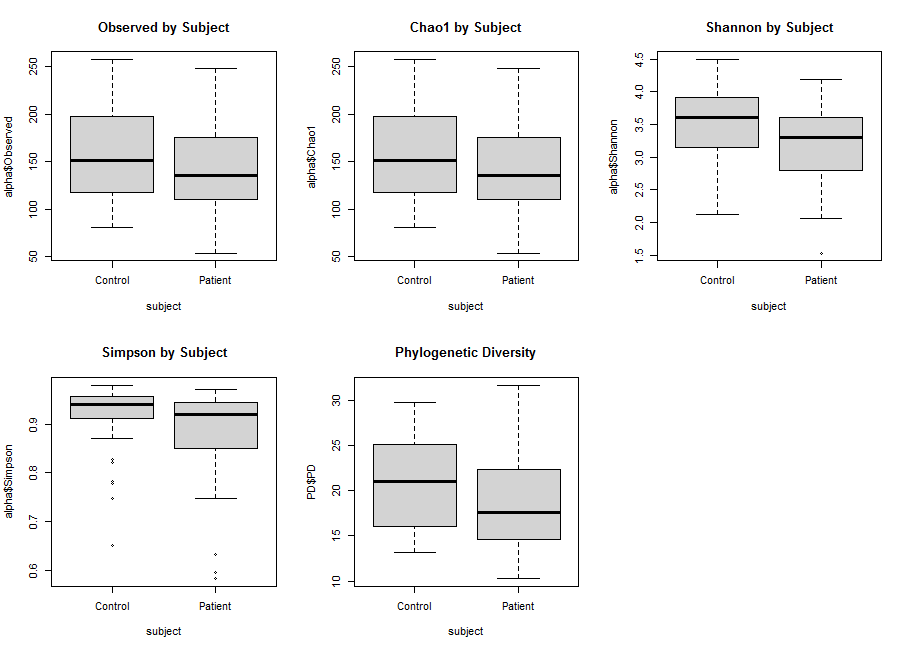

Veiem que els resultats varien segons el càlcul, per això sempre resulta molt útil comparar el resultat entre diversos mètodes. Per avaluar l’efecte dels diferents paràmetres de filtrat inicial sobre els resultats vaig canviar el valor de les línies de codi 201 i 203 de l’apartat “Carregar objecte phyloseq i preprocessament” per 10, 50 i 1000, i per observar el resultat sense filtrat vaig utilitzar l’objecte filoseq sense executar les línies de codi 201 i 203, encara que substituir el seu valor per 0 i executar-les tindria el mateix efecte. Per avaluar els efectes de la rarefacció simplement vaig utilitzar raredata en comptes de phyloseq.

# 9 Diversitat beta

I seguidament estimarem la diversitat beta o diversitat entre mostres, que no deixa de ser un càlcul de distància entre mostres.

```r
##Diversitat beta
#Distància Bray-Curtis
bray <- phyloseq::distance(phyloseq, method = "bray")
#Distància Unifrac
#Es recomana calcular la distància unifrac utilitzant dades rarefaccionades, ho faig de les dues maneres per comparar
unifrac <- phyloseq::distance(phyloseq, method = "unifrac")
unifracRare <- phyloseq::distance(raredata, method = "unifrac")
#Distància Unifrac ponderada
wunifrac <- phyloseq::distance(phyloseq, method = "wunifrac")
wunifracRare <- phyloseq::distance(raredata, method = "wunifrac")
#Distància de Jaccard
jaccard <- phyloseq::distance(phyloseq, method = "jaccard", binary = TRUE)
```

Podem comprovar si hi ha diferències significatives entre les distàncies dels controls i dels pacients amb un PERMANOVA fent servir la funció adonis del paquet vegan.

```r
#Estudiem si hi ha diferències significatives entre les distàncies dels controls i dels pacients amb un PERMANOVA
adonis(bray~subject)
adonis(unifrac~subject)
adonis(unifracRare~subject)
adonis(wunifrac~subject)
adonis(wunifracRare~subject)
adonis(jaccard~subject)
```

## 9.1 Representació de la diversitat beta

Una vegada hem calculat les distàncies podem representar-les per facilitar-ne la interpretació. Per fer-ho primer hem de fer una ordinació MDS (multidimensional scaling) o NMDS (la versió no mètrica de l’anterior), i representar-la gràficament.

```r
##MDS
#Ordinació MDS distància Bray-Curtis
bray.MDS = ordinate(phyloseq, "MDS", distance = bray)
#Representació
plot_ordination(phyloseq, bray.MDS, color = "Subject")
#Ordinació MDS distància Unifrac
unifrac.MDS = ordinate(phyloseq, "MDS", distance = unifrac)
unifrac.MDS.Rare = ordinate(raredata, "MDS", distance = unifrac)
#Representació
plot_ordination(phyloseq, unifrac.MDS, color = "Subject")
plot_ordination(raredata, unifrac.MDS.Rare, color = "Subject")
#Ordinació MDS distància Unifrac ponderada
wunifrac.MDS = ordinate(phyloseq, "MDS", distance = wunifrac)
wunifrac.MDS.Rare = ordinate(raredata, "MDS", distance = wunifrac)
#Representació
plot_ordination(phyloseq, wunifrac.MDS, color = "Subject")
plot_ordination(raredata, wunifrac.MDS.Rare, color = "Subject")
#Ordinació MDS distància Jaccard
jaccard.NMDS = ordinate(phyloseq, "MDS", distance = jaccard)
#Representació
plot_ordination(phyloseq, jaccard.NMDS, color = "Subject")

##NMDS, no mostrat a la memòria
#Ordinació NMDS distància Bray-Curtis
bray.NMDS = ordinate(phyloseq, "NMDS", distance = bray)
#Representació
plot_ordination(phyloseq, bray.NMDS, color = "Subject")
#Ordinació NMDS distància Unifrac
unifrac.NMDS = ordinate(phyloseq, "NMDS", distance  = unifrac)
unifrac.NMDS.Rare = ordinate(raredata, "NMDS", distance  = unifrac)
#Representació
plot_ordination(phyloseq, unifrac.NMDS, color = "Subject")
plot_ordination(raredata, unifrac.NMDS.Rare, color = "Subject")
#Ordinació NMDS distància Unifrac ponderada
wunifrac.NMDS = ordinate(phyloseq, "NMDS", distance  = wunifrac)
wunifrac.NMDS.Rare = ordinate(raredata, "NMDS", distance  = wunifrac)
#Representació
plot_ordination(phyloseq, wunifrac.NMDS, color = "Subject")
plot_ordination(raredata, wunifrac.NMDS.Rare, color = "Subject")
#Ordinació NMDS distància Jaccard
jaccard.NMDS = ordinate(phyloseq, "NMDS", distance  = jaccard)
#Representació
plot_ordination(phyloseq, jaccard.NMDS, color = "Subject")
```

Representació de la ordinació MDS de les distàncies Bray-Curtis:

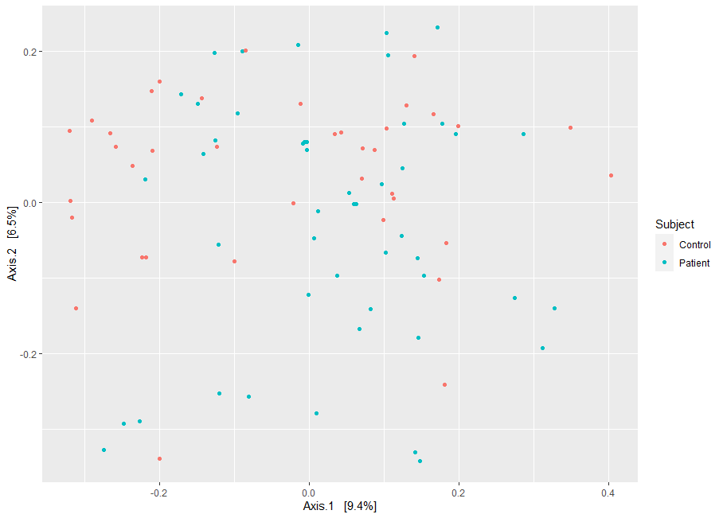

Representació de la ordinació MDS de les distàncies UniFrac no ponderades:

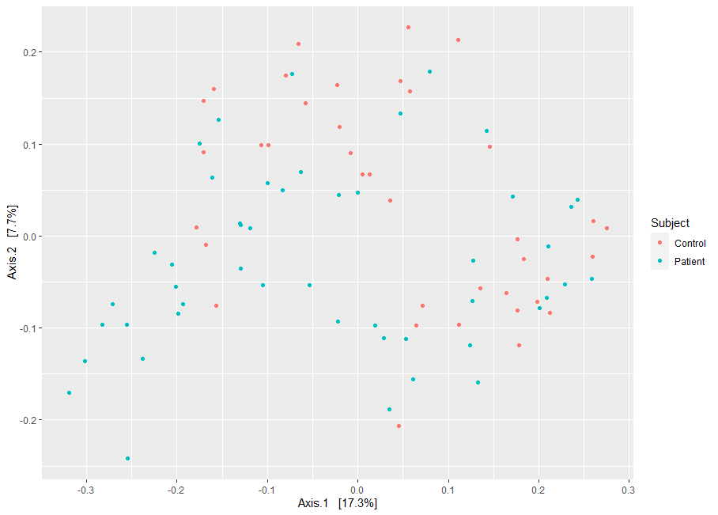

Representació de la ordinació MDS de les distàncies UniFrac ponderades:

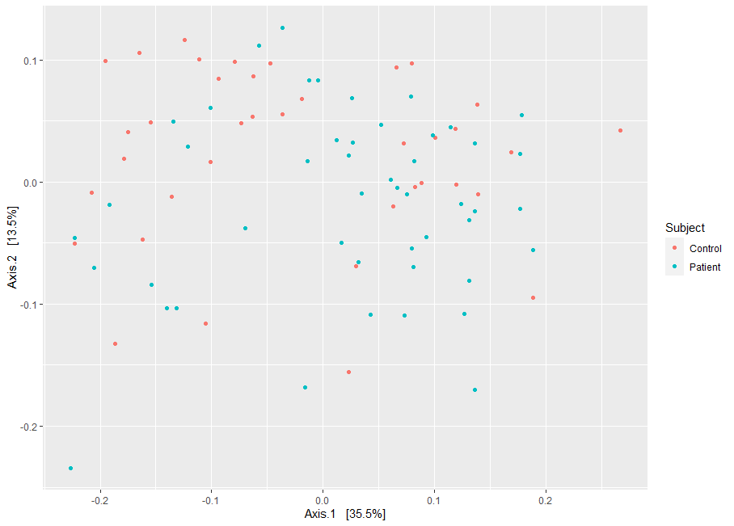

Representació de la ordinació MDS de les distàncies de Jaccard:

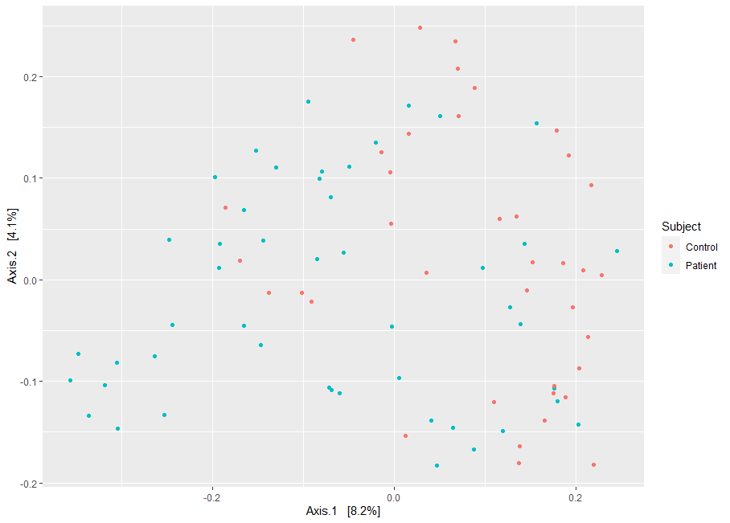

# 10 Prova d’abundàncies diferencials

Per la prova d’abundàncies diferencials farem servir aldex del paquet ALDEx2, que és una de les funcions més senzilles d’utilitzar per aquest propòsit.

```r
#Aldex2, transposo la taula d'OTUs per tenir les mostres a les columnes com demana la funció
aldexTest <- aldex(t(otu_table(phyloseq)), subject, test="t", effect = TRUE, verbose = TRUE, denom = "zero")
View(aldexTest)
par(mfrow=c(1,1))
aldex.plot(aldexTest, type="MW", test="wilcox")
#Comprovem quina taxonomia es va assignar a les ASVs diferencialment abundants
tax_table(phyloseq)["ASV80"]
tax_table(phyloseq)["ASV65"]
tax_table(phyloseq)["ASV74"]
tax_table(phyloseq)["ASV113"]
tax_table(phyloseq)["ASV29"]
tax_table(phyloseq)["ASV73"]
tax_table(phyloseq)["ASV62"]
tax_table(phyloseq)["ASV23"]
tax_table(phyloseq)["ASV27"]
tax_table(phyloseq)["ASV22"]
tax_table(phyloseq)["ASV37"]
tax_table(phyloseq)["ASV67"]
tax_table(phyloseq)["ASV72"]
tax_table(phyloseq)["ASV100"]

#Mateixa prova a nivell fílum
phylum <- tax_glom(phyloseq, "Phylum")
taxa_names(phylum) <- tax_table(phylum)[, "Phylum"]
aldexPhylum <- aldex(t(otu_table(phylum)), subject, test="t", effect = TRUE, verbose = TRUE, denom = "zero")
View(aldexPhylum)
par(mfrow=c(1,1))
aldex.plot(aldexPhylum, type="MW", test="wilcox")
```

Taula amb els resultats d’executar la funció aldex. El p-valor considerat va ser el de la dreta de tot (wi.eBH) que és el p-valor corregit per Benjamini-Hochberg:

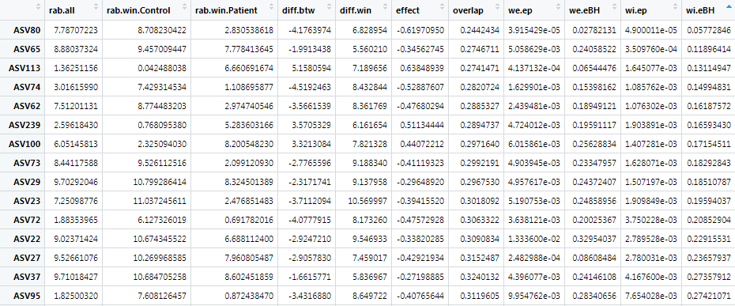

Representació MW:

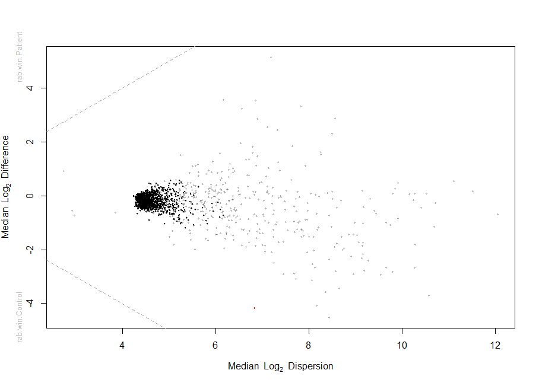

L’avaluació de diferents paràmetres de filtrat i els efectes de la rarefacció es van avaluar com en els dos casos anteriors. Per la respresentació dels fílums diferencialment abundants es va fer servir la funció plot_tree, la seva execució es troba dins al subapartat “Diagrama de caixes , arbre filogenètic i heatmap” a la secció “Arbre filogenètic”.

# 11 Selecció de balanços

Finalment podem intentar seleccionar balanços entre ASVs que es puguin associar a la condició mitjançant selbal i CoDaCoRe. Proves fetes al nivell taxonòmic família.

```r
##Selbal
dev.off() #Netejar finestra
family <- tax_glom(phyloseq, "Family")
taxa_names(family) <- tax_table(family)[,"Family"]
x <- otu_table(family)
x <- x + 1
balance <- selbal(x, as.factor(subject))
balance
#Diagrama del balanç
dev.off() #Netejar finestra
grid.draw(balance$global.plot2)
#Precisió de predicció del balanç seleccionat
dev.off() #Netejar finestra
balance$ROC.plot

##CoDaCoRe
model = codacore(
  x, #Taula
  subject, #Variable resposta
  logRatioType = "balances", #Selecció de balanços
  lambda = 1 #Força de la regularització
)
print(model)
plot(model)
```

Resultat del selbal:

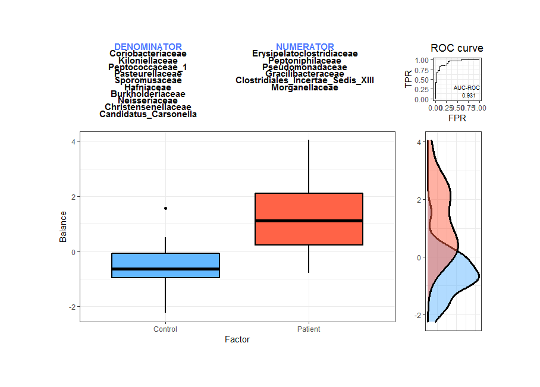

I del CoDaCoRe:

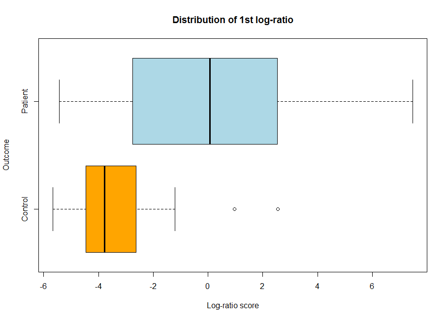

L’avaluació de diferents paràmetres de filtrat es va fer com en els tres casos anteriors. Per aquests mètodes no vaig avaluar els efectes de la rarefacció.

# 12 Referències

Calle, M. Statistical Methods for Microbiome Analysis. Retrieved 12/11/2020.

Callahan, B., Sankaran, K., Fukuyama, J., McMurdie, P., & Holmes, S. (2017). Workflow for Microbiome Data Analysis: from raw reads to community analyses. Retrieved 28/05/2021, from http://web.stanford.edu/class/bios221/MicrobiomeWorkflowII.html

Callahan, B. DADA2 Pipeline Tutorial (1.16). Retrieved 28/05/2021, from https://benjjneb.github.io/dada2/tutorial.html

Callahan, B. DADA2 ITS Pipeline Workflow (1.8). Retrieved 28/05/2021, from https://benjjneb.github.io/dada2/ITS_workflow.html

Ollberding, N. (2019). Introduction to the Statistical Analysis of Microbiome Data in R. Retrieved 17/04/2021, from https://www.nicholas-ollberding.com/post/introduction-to-the-statistical-analysis-of-microbiome-data-in-r/

Calle, M. Nice plots with R. Retrieved 03/06/2021.